# Basketball

Next we will check how effective the home court advantage is

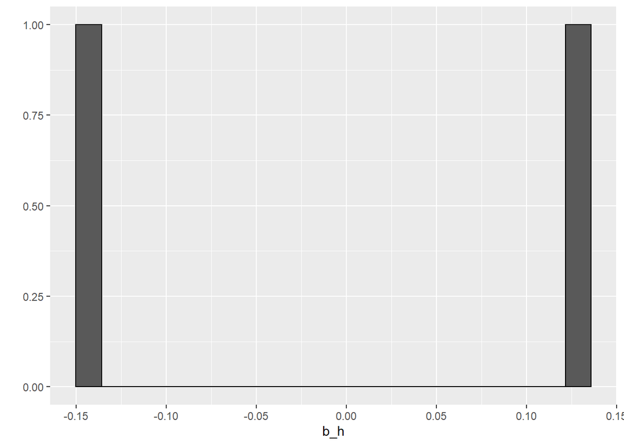

```r
#Add Home/Away Effect
home_ave <- train_set %>%
  group_by(Home) %>%
  summarize(b_h = mean(PTS - mu))
home_ave %>% qplot(b_h, geom ="histogram", bins = 20, data = ., color = I("black"))
```

```r
predicted_home_ave <- test_set %>%
  left_join(player_ave, by='Player') %>%
  left_join(home_ave, by='Home') %>%
  mutate(pred = mu + b_p + b_h)
rmse_home <- RMSE(test_set_full$PTS,predicted_home_ave$pred)
rmse_results <- bind_rows(rmse_results,
                          data_frame(method="Add Home Model",
                                     RMSE = rmse_home ))
rmse_results
```

```
## # A tibble: 3 x 2
##   method                     RMSE
##   <chr>                     <dbl>
## 1 Using mean only      7.90216151
## 2 Player History Model 5.97132342
## 3 Add Home Model       5.97118446
```

The player playing home or away makes a slight difference to projected points

Next we can check to see how normalizing for the players position affects the algorithm

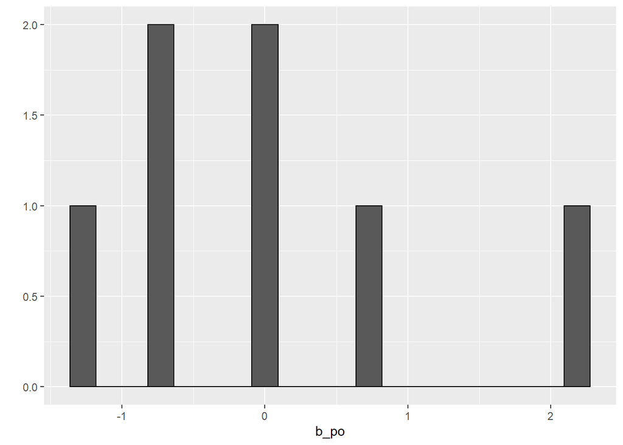

```r
#Add Position
pos_ave <- train_set %>%
  group_by(Pos) %>%
  summarize(b_po = mean(PTS - mu))
pos_ave %>% qplot(b_po, geom ="histogram", bins = 20, data = ., color = I("black"))
```

```r
predicted_pos_ave <- test_set %>%
  left_join(player_ave, by='Player') %>%
  left_join(home_ave, by='Home') %>%
  left_join(pos_ave, by='Pos') %>%
  mutate(pred = mu + b_p + b_h + b_po)
rmse_pos <- RMSE(test_set_full$PTS,predicted_pos_ave$pred)
rmse_results <- bind_rows(rmse_results,
                          data_frame(method="Add Position Model",
                                     RMSE = rmse_pos ))

rmse_results
```

```
## # A tibble: 4 x 2
##   method                     RMSE
##   <chr>                     <dbl>
## 1 Using mean only      7.90216151
## 2 Player History Model 5.97132342
## 3 Add Home Model       5.97118446
## 4 Add Position Model   6.03393443
```

```r
#Note that adding in the position average actually made the model worse - it could be because we are already
#including position by virtue of including the player, and therefore double counting
```

We would expect the RMSE to decrease, because position has a correlation to points. But since we are already using the player, which will intrinsically include position - adding in position as well actually makes our model worse. Basically doubling up on position as a variable.

Just to be sure we are using the best predictor, we can check what the model looks like with position instead of player

```r
#Let's remove the player model and see if the position is a more accurate determinate
predicted_pos_ave <- test_set %>%
  left_join(home_ave, by='Home') %>%
  left_join(pos_ave, by='Pos') %>%
  mutate(pred = mu + b_h + b_po)
rmse_pos <- RMSE(test_set_full$PTS,predicted_pos_ave$pred)
rmse_results <- bind_rows(rmse_results,
                          data_frame(method="Position without Player",
                                     RMSE = rmse_pos ))

rmse_results
```

```
## # A tibble: 5 x 2
##   method                        RMSE
##   <chr>                        <dbl>
## 1 Using mean only         7.90216151
## 2 Player History Model    5.97132342
## 3 Add Home Model          5.97118446
## 4 Add Position Model      6.03393443
## 5 Position without Player 7.86274606
```

```r
#Clearly using a players direct history is more useful than the position alone
```

That is a much worse RMSE value, so we know player is a better predictor and we can remove position from the model

Next we can check age

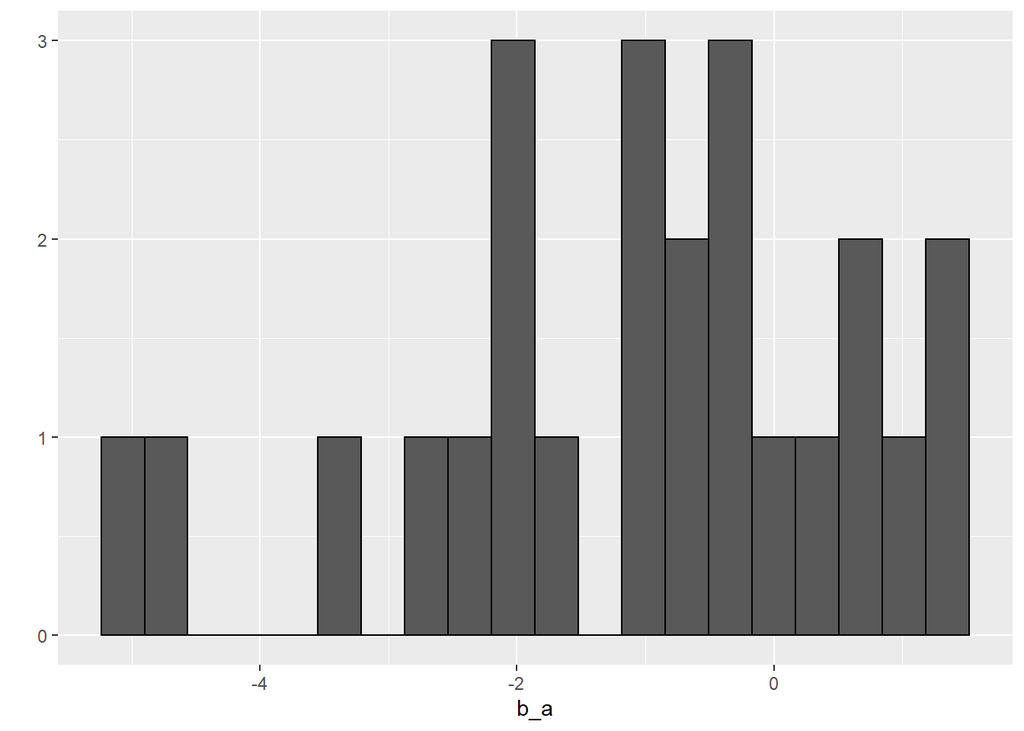

```r
age_ave <- train_set %>%
  group_by(Age) %>%
  summarize(b_a = mean(PTS - mu))
age_ave %>% qplot(b_a, geom ="histogram", bins = 20, data = ., color = I("black"))
```

```r
predicted_age_ave <- test_set %>%
  left_join(player_ave, by='Player') %>%
  left_join(home_ave, by='Home') %>%
  left_join(age_ave, by='Age') %>%
  mutate(pred = mu + b_p + b_h + b_a)
rmse_age <- RMSE(test_set_full$PTS,predicted_age_ave$pred)
rmse_results <- bind_rows(rmse_results,
                          data_frame(method="Add Age Model (Position removed)",
                                     RMSE = rmse_age ))

rmse_results
```

```
## # A tibble: 6 x 2
##   method                                 RMSE
##   <chr>                                 <dbl>
## 1 Using mean only                  7.90216151
## 2 Player History Model             5.97132342
## 3 Add Home Model                   5.97118446
## 4 Add Position Model               6.03393443
## 5 Position without Player          7.86274606
## 6 Add Age Model (Position removed) 5.99375036
```

```r
#We see the same result with Age as with position. Clearly the "Player" factors are covered by using that player's history
#Instead we will focus on the "game" factors.
```

Age seems to be similar to position, in that it is already included by virtue of having Player in the model. We will change our focus to “Game” factors, since player factors are likely automatically included in Player

We know that as years pass, there is a higher average points - so we can include year in the model as well.

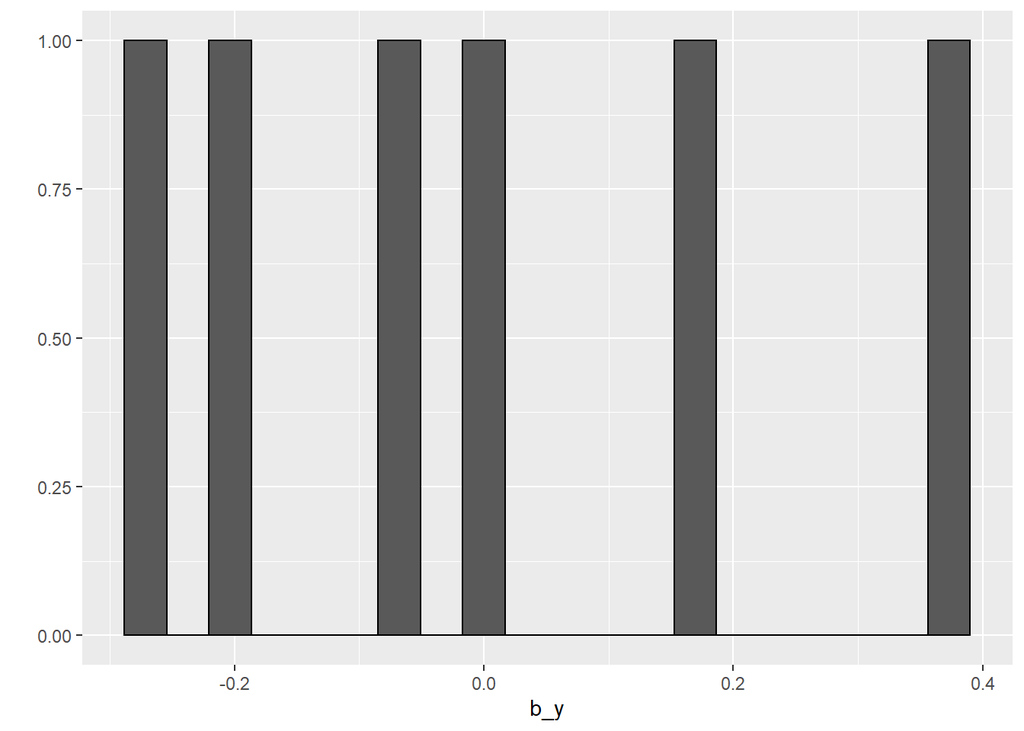

```r
year_ave <- train_set %>%
  group_by(Year) %>%
  summarize(b_y = mean(PTS - mu))
year_ave %>% qplot(b_y, geom ="histogram", bins = 20, data = ., color = I("black"))
```

```r
predicted_year_ave <- test_set %>%
  left_join(player_ave, by='Player') %>%
  left_join(home_ave, by='Home') %>%
  left_join(year_ave, by='Year') %>%
  mutate(pred = mu + b_p + b_h + b_y)
rmse_year <- RMSE(test_set_full$PTS,predicted_year_ave$pred)
rmse_results <- bind_rows(rmse_results,
                          data_frame(method="Add Year Model (Age Removed)",
                                     RMSE = rmse_year ))
rmse_results
```

```
## # A tibble: 7 x 2
##   method                                 RMSE
##   <chr>                                 <dbl>
## 1 Using mean only                  7.90216151
## 2 Player History Model             5.97132342
## 3 Add Home Model                   5.97118446
## 4 Add Position Model               6.03393443
## 5 Position without Player          7.86274606
## 6 Add Age Model (Position removed) 5.99375036
## 7 Add Year Model (Age Removed)     5.96757729
```

That has a slight effect as well, so we will include it in the model

Finally we will check the opponent

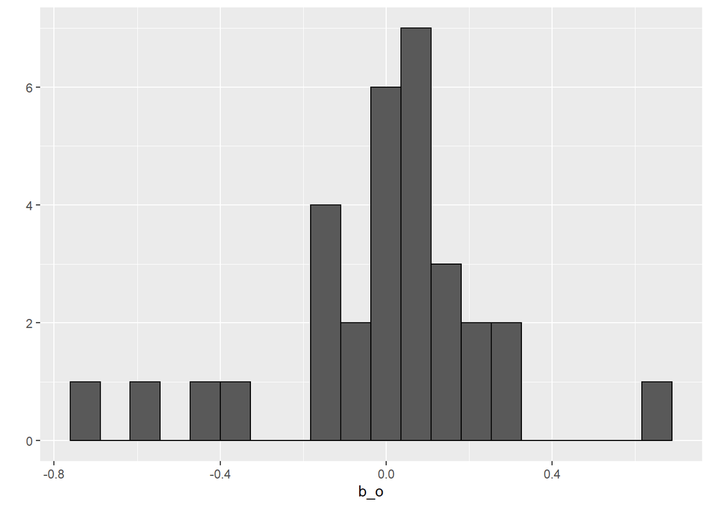

```r
#opponent included
opp_ave <- train_set %>%
  group_by(Opp) %>%
  summarize(b_o = mean(PTS - mu))
opp_ave %>% qplot(b_o, geom ="histogram", bins = 20, data = ., color = I("black"))
```

```r
predicted_opp_ave <- test_set %>%
  left_join(player_ave, by='Player') %>%
  left_join(home_ave, by='Home') %>%
  left_join(year_ave, by='Year') %>%
  left_join(opp_ave, by='Opp') %>%
  mutate(pred = mu + b_p + b_h + b_y + b_o)
rmse_opp <- RMSE(test_set_full$PTS,predicted_opp_ave$pred)
rmse_results <- bind_rows(rmse_results,
                          data_frame(method="Add Opponent",
                                     RMSE = rmse_opp ))
rmse_results
```

```
## # A tibble: 8 x 2
##   method                                 RMSE
##   <chr>                                 <dbl>
## 1 Using mean only                  7.90216151
## 2 Player History Model             5.97132342
## 3 Add Home Model                   5.97118446
## 4 Add Position Model               6.03393443
## 5 Position without Player          7.86274606
## 6 Add Age Model (Position removed) 5.99375036
## 7 Add Year Model (Age Removed)     5.96757729
## 8 Add Opponent                     5.96671254
```

Again there is a slight effect

```r
rmse_results %>% knitr::kable()
```

| method | RMSE |
| --- | --- |
| Using mean only | 7.902162 |
| Player History Model | 5.971323 |
| Add Home Model | 5.971184 |
| Add Position Model | 6.033934 |
| Position without Player | 7.862746 |
| Add Age Model (Position removed) | 5.993750 |
| Add Year Model (Age Removed) | 5.967577 |
| Add Opponent | 5.966712 |

Now that we have learned from our liner regression, we can attempt to use the useful variables to create a decision tree that will help predict whether a player will reach a score of 22 points or more First we will create a dataset with just the useful factors to make it easier to manage. Then we will set the test and training sets again

```r
#create a dataset that uses only the colums we found to be good predicters in the linear regression modelling
Kdat <- dat %>% select(Player, Pos, Year, Opp, Home, Gr22)

#Dependant variable is a factor
Kdat$Gr22 <- factor(Kdat$Gr22)

#Make year a factor instead of numerical
Kdat$Year <- factor(Kdat$Year)

#maintain consistency with test and training sets
set.seed(1)


test_index <- createDataPartition(y = dat$PTS, times = 1, p = 0.5, list = FALSE)


train_set <- Kdat[-test_index,]
temp <- Kdat[test_index,]

# Make sure all players in test set are also in train set
test_set <- temp %>%
  semi_join(train_set, by = "Player")

# Add rows removed from test_set set back into train_set set

removed <- anti_join(temp, test_set)
train_set <- rbind(train_set, removed)

rm( test_index, temp, removed)
```

```r
#create a tree using Player, year, opponent and home variables (the ones linear regression showed us a relationship to pts with)

mytree <- rpart(
  Gr22 ~.,
  data = train_set[1:6],
  method = "class",
control =rpart.control(minsplit =1,minbucket=1, cp=0.001)
)

#Explore the tree
mytree
```

```
## n= 64762
##
## node), split, n, loss, yval, (yprob)
##       * denotes terminal node
##
##    1) root 64762 5669 No (0.91246410 0.08753590)
##      2) Player=Ã–mer AÅŸÄ±k,A.J. Hammons,A.J. Price,Ãlex Abrines,Aaron Brooks,Aaron Gordon,Aaron Gray,Aaron Harrison,Abdel Nader,Adreian Payne,Al-Farouq Aminu,Al Harrington,Al Horford,Al Jefferson,Alan Anderson,Alan Williams,Alec Burks,Alec Peters,Alex Caruso,Alex Len,Alex Poythress,Alexey Shved,…
##      3) Player=Andrew Wiggins,Anthony Davis,Blake Griffin,Bradley Beal,Brandon Knight,Brook Lopez,Carmelo Anthony,Chris Bosh,Chris Paul,CJ McCollum,Damian Lillard,Danilo Gallinari,DeMar DeRozan,DeMarcus Cousins,Derrick Rose,Devin Booker,Donovan Mitchell,Dwyane Wade,Eric Bledsoe,Giannis Antetokoun…
##        6) Player=Andrew Wiggins,Bradley Beal,Brandon Knight,Brook Lopez,Chris Bosh,Chris Paul,CJ McCollum,Danilo Gallinari,Derrick Rose,Devin Booker,Dwyane Wade,Eric Bledsoe,Giannis Antetokounmpo,Goran DragiÄ‡,Gordon Hayward,Jimmy Butler,John Wall,Jrue Holiday,Kawhi Leonard,Kemba Walker,Kevin Lov…
##         12) Year=2013,2014,2015 2271  615 No (0.72919419 0.27080581) *
##         13) Year=2016,2017,2018 2315  888 No (0.61641469 0.38358531)
##           26) Player=Andrew Wiggins,Brandon Knight,Brook Lopez,Chris Paul,Danilo Gallinari,Derrick Rose,Dwyane Wade,Eric Bledsoe,Goran DragiÄ‡,Jrue Holiday,Kevin Love,Kevin Martin,Kobe Bryant,Kristaps PorziÅ†Ä£is,Marc Gasol,Mike Conley,Paul Millsap,Rudy Gay,Victor Oladipo 1302  378 No (0.70967742…
##           27) Player=Bradley Beal,Chris Bosh,CJ McCollum,Devin Booker,Giannis Antetokounmpo,Gordon Hayward,Jimmy Butler,John Wall,Kawhi Leonard,Kemba Walker,Klay Thompson,Kyle Lowry 1013  503 Yes (0.49654492 0.50345508)
##             54) Opp=ATL,CHI,CLE,DAL,DEN,DET,GSW,HOU,IND,LAC,MEM,MIA,MIL,MIN,NOP,OKC,ORL,SAC,SAS,UTA,WAS 704  316 No (0.55113636 0.44886364)
##              108) Player=Bradley Beal,Chris Bosh,Devin Booker,Gordon Hayward,Jimmy Butler,John Wall,Kyle Lowry 374  146 No (0.60962567 0.39037433) *
##              109) Player=CJ McCollum,Giannis Antetokounmpo,Kawhi Leonard,Kemba Walker,Klay Thompson 330  160 Yes (0.48484848 0.51515152)
##                218) Opp=DEN,DET,GSW,HOU,LAC,MEM,NOP,OKC,SAC,UTA,WAS 186   83 No (0.55376344 0.44623656)
##                  436) Year=2016,2018 118   46 No (0.61016949 0.38983051) *
##                  437) Year=2017 68   31 Yes (0.45588235 0.54411765)
##                    874) Player=CJ McCollum,Kawhi Leonard 26    9 No (0.65384615 0.34615385) *
##                    875) Player=Giannis Antetokounmpo,Kemba Walker,Klay Thompson 42   14 Yes (0.33333333 0.66666667) *
##                219) Opp=ATL,CHI,CLE,DAL,IND,MIA,MIL,MIN,ORL,SAS 144   57 Yes (0.39583333 0.60416667) *
##             55) Opp=BOS,BRK,CHO,LAL,NYK,PHI,PHO,POR,TOR 309  115 Yes (0.37216828 0.62783172) *
##        7) Player=Anthony Davis,Blake Griffin,Carmelo Anthony,Damian Lillard,DeMar DeRozan,DeMarcus Cousins,Donovan Mitchell,Isaiah Thomas,James Harden,Joel Embiid,Karl-Anthony Towns,Kevin Durant,Kyrie Irving,LaMarcus Aldridge,LeBron James,Paul George,Russell Westbrook,Stephen Curry 2778 1061 Yes …
##         14) Player=Blake Griffin,Carmelo Anthony,Damian Lillard,DeMar DeRozan,Donovan Mitchell,Isaiah Thomas,Joel Embiid,Karl-Anthony Towns,Kyrie Irving,LaMarcus Aldridge,Paul George 1553  729 Yes (0.46941404 0.53058596)
##           28) Year=2015 257  106 No (0.58754864 0.41245136)
##             56) Opp=ATL,BOS,CHI,CHO,CLE,DAL,DEN,GSW,IND,LAL,MEM,MIL,MIN,NOP,NYK,OKC,PHI,PHO,POR,SAS,UTA,WAS 184   61 No (0.66847826 0.33152174) *
##             57) Opp=BRK,DET,HOU,LAC,MIA,ORL,SAC,TOR 73   28 Yes (0.38356164 0.61643836)
##              114) Player=Carmelo Anthony,Isaiah Thomas,Karl-Anthony Towns 22    8 No (0.63636364 0.36363636) *
##              115) Player=Blake Griffin,Damian Lillard,DeMar DeRozan,Kyrie Irving,LaMarcus Aldridge,Paul George 51   14 Yes (0.27450980 0.72549020) *
##           29) Year=2013,2014,2016,2017,2018 1296  578 Yes (0.44598765 0.55401235)
##             58) Opp=ATL,BRK,CHA,CHI,CHO,CLE,DAL,DEN,DET,GSW,HOU,LAC,LAL,MEM,MIA,MIL,MIN,NOP,OKC,ORL,PHI,PHO,POR,SAC,SAS,UTA 1076  505 Yes (0.46933086 0.53066914)
##              116) Opp=CHA,HOU,LAC,PHO,SAC,UTA 219  100 No (0.54337900 0.45662100)
```

[output cut: 17 more lines]

[figure not shown]

```r
#This one becomes a bit of a mess, because there are so many players names to include in the tree. We could exlude the player data for the sake of getting a neater tree,
#however it would be a shame to lose our best available predictor and the overall accuracy would decrease quite a bit
fancyRpartPlot(mytree, caption = NULL)
```

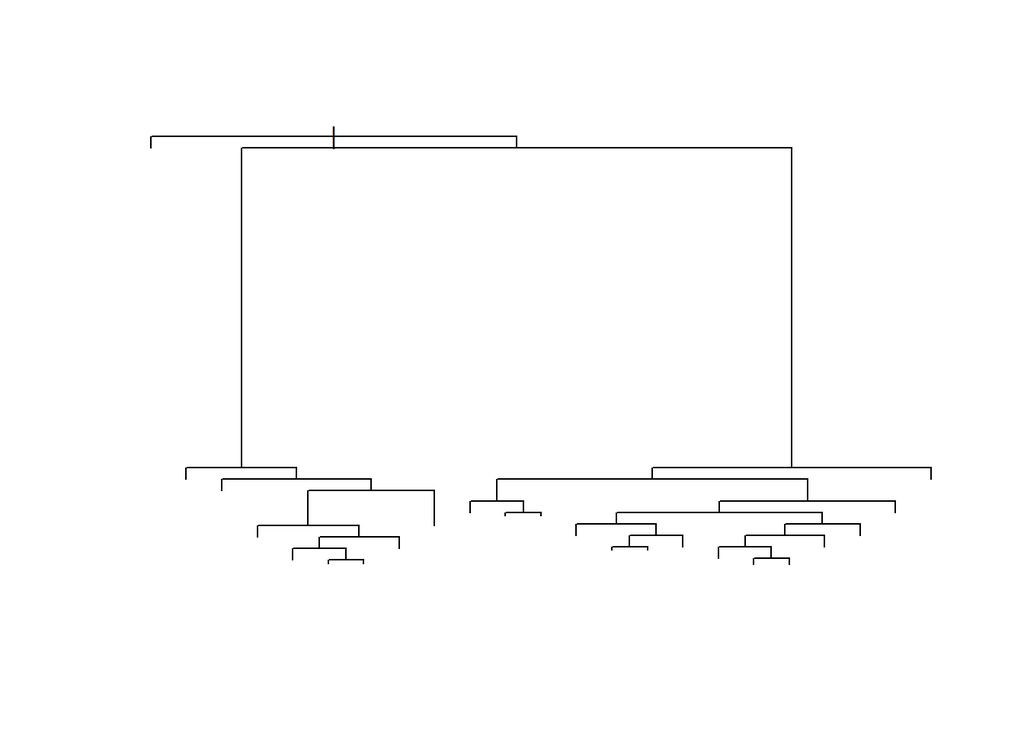

```r
plot(mytree)
```

As we can see in the plotting, the visual of the tree is a bit messy, since there are player names inlcuded and we have 868 players which split into different groups but retain all of the names for future predictablility, so displaying the different splits makes a bit of a mess

## Results

```r
#generate predictions for a test set
pred <- predict(mytree, test_set, type = "class")

#change Gr22 to a factor for comparison
test_set_full$Gr22 <- factor(test_set_full$Gr22)

#generate confusion matrix
confusionMatrix(pred, test_set_full$Gr22)
```

```
## Confusion Matrix and Statistics
##
##           Reference
## Prediction    No   Yes
##        No  57960  3998
##        Yes  1109  1698
##
##                Accuracy : 0.9211
##                  95% CI : (0.919, 0.9232)
##     No Information Rate : 0.9121
##     P-Value [Acc > NIR] : < 2.2e-16
##
##                   Kappa : 0.3624
##
##  Mcnemar's Test P-Value : < 2.2e-16
##
##             Sensitivity : 0.9812
##             Specificity : 0.2981
##          Pos Pred Value : 0.9355
##          Neg Pred Value : 0.6049
##              Prevalence : 0.9121
##          Detection Rate : 0.8949
##    Detection Prevalence : 0.9567
##       Balanced Accuracy : 0.6397
##
##        'Positive' Class : No
##
```

```r
#check accuracy
accuracy <- postResample(pred, test_set_full$Gr22)
accuracy
```

```
##  Accuracy     Kappa
## 0.9211457 0.3623627
```

Generating a confusion matrix shows us that the model predicts whether a player will score 22 or more points with 92% accuracy. This sounds pretty good, but a deeper look shows that we have a lot of players that score 22 or greater that we fail to predict. This is not a terrible result, because we don’t need to predict all of the players correctly, but we do want to be sure that we are not predicting too many players to be greater than 22 and getting it wrong. After all, we only need to choose 9 players for a team.

A more accurate model might take into account each of the different statistics that are tracked in daily fantasy sports, in order to get a more well rounded estimate. We might also do a formula where we divide projected points by the daily fantasy sports cost in order to get a points/dollar estimate of the players projected performance. That data is available from betting sites, but it is typically in the format of one nights games per excel sheet, so it would require more extensive scraping and stitching together of data to have a useful set for machine learning.

## Conclusion

With a data set of points per game from previous games played, we can make a prediciton of the points a player will get within approximately 6 points using linear regression. Using a decision tree we can attempt to determine which players will score above a threshold with an accuracy of approximately 92%. With additional factors for daily fantasy sports we might be able to get a more accurate prediction. If we could include injury data and team lineups, we could attempt to predict when an injury will lead to increased playing time for a player. That can often predict whether they score well above their daily fantasy sports score.